# Concentration of S&P 500 index

In this data challege we study how concentrated the S&P 500 is among its constituent companies.

1. The S&P 500 (Standard & Poor’s 500) is a stock market index that tracks the performance of 500 of the largest publicly traded companies in the United States.
2. It covers roughly 80% of the total value of the U.S. stock market.
3. It is a market-capitalization-weighted index. Larger companies have a much bigger impact on its value than smaller components

We will use:

```r
library(tidyquant)    #retrieve the S&P 500 constituents and weights
library(tidyverse)    #manipulate and visualize the data
library(ineq)         #calculate the Lorenz curve and Gini coefficient
```

# Questions

1. How unequal are the company weights in the S&P 500?
2. How much of the index is represented by its largest companies?
3. What does the Lorenz curve tell us about concentration?
4. What is the Gini coefficient of the S&P 500 weights?

# Getting the data

First, we need to get the data from the S&P 500 index.

```r
# create data folder if there is none
if(!dir.exists("data")){
  dir.create("data")
}

if (!file.exists("data/sp500.csv")){
# get sp500 index data
  sp500 = tq_index("SP500")
  write_csv(sp500, "data/sp500.csv")
}

sp500 = read_csv("data/sp500.csv")
sp500
```

```
## # A tibble: 505 × 8
##    symbol company      identifier sedol weight sector shares_held local_currency
##    <chr>  <chr>        <chr>      <chr>  <dbl> <chr>        <dbl> <chr>
##  1 NVDA   NVIDIA CORP  67066G104  2379… 0.0791 -        295426533 USD
##  2 AAPL   APPLE INC    037833100  2046… 0.0759 -        178161925 USD
##  3 MSFT   MICROSOFT C… 594918104  2588… 0.0591 -         90642802 USD
##  4 AMZN   AMAZON.COM … 023135106  2000… 0.0372 -        119819482 USD
##  5 GOOGL  ALPHABET IN… 02079K305  BYVY… 0.0282 -         71631987 USD
##  6 AVGO   BROADCOM INC 11135F101  BDZ7… 0.0244 -         58077784 USD
##  7 GOOG   ALPHABET IN… 02079K107  BYY8… 0.0226 -         58024852 USD
##  8 META   META PLATFO… 30303M102  B7TL… 0.0205 -         26919008 USD
##  9 TSLA   TESLA INC    88160R101  B616… 0.0172 -         34405368 USD
## 10 MU     MICRON TECH… 595112103  2588… 0.0157 -         13787393 USD
## # ℹ 495 more rows
```

This includes a bit more than 500 companies (505) because there are titles associated with the same company (for example GOOGL and GOOG).

# Unequality

We want to measure how unequal are the company weights in the top 500 companies by market cap (SP500 index). Let’s start by creating a tibble with the cumulative share and plot it.

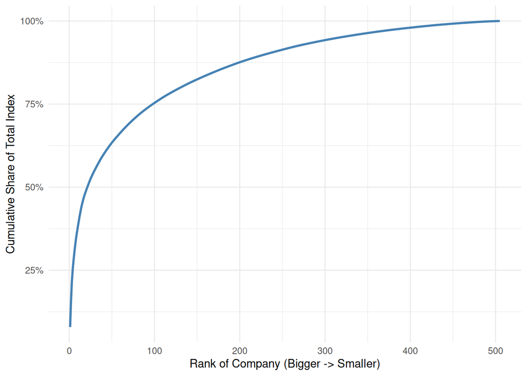

```r
# cumulative data
sp500_ranked = sp500 |>
  arrange(desc(weight)) |>
  mutate(
    rank = row_number(),
    cumulative_weight = cumsum(weight)
  )

ggplot(sp500_ranked, aes(x = rank, y = cumulative_weight)) +
  geom_line(color = "steelblue", linewidth = 1) +
  scale_y_continuous(labels = scales::percent) +
  labs(
    x = "Rank of Company (Bigger -> Smaller)",
    y = "Cumulative Share of Total Index"
  ) +
  theme_minimal()
```

Visually, we can see that a small share of big companies at the top ranking are holding a big share of the SP500 index. Let’s see it in numbers by calculating the share for the top 5, 10 and 20 respectively.

```r
top5 = sp500_ranked |> filter(rank <= 5)
top10 = sp500_ranked |> filter(rank <= 10)
top20 = sp500_ranked |> filter(rank <= 20)
sum(top5$weight)
```

```
## [1] 0.2796215
```

```r
sum(top10$weight)
```

```
## [1] 0.3800656
```

```r
sum(top20$weight)
```

```
## [1] 0.4917334
```

We can observe that:

- The top 5 companies hold ~$28\%$ of the shares.
- The top 10 companies hold ~$38\%$ of the shares.
- The top 20 companies hold ~$49\%$ of the shares.

# Lorenz curve

To better see the unequality let’s draw the lorenz curve.

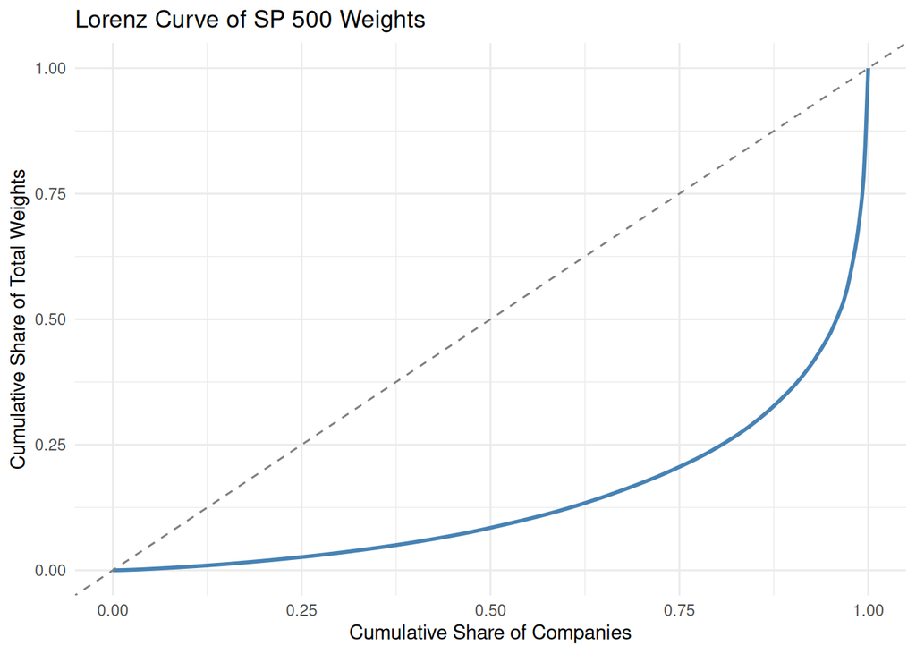

```r
ldata = Lc(sp500$weight)
df_ldata = data.frame(p = ldata$p, L = ldata$L)


ggplot(df_ldata, aes(x = p, y = L)) +
  # lorentz curve
  geom_line(color = "steelblue", linewidth = 1) +
  # diagonal
  geom_abline(intercept = 0, slope = 1, linetype = "dashed", color = "gray50") +
  labs(
    title = "Lorenz Curve of SP 500 Weights",
    x = "Cumulative Share of Companies",
    y = "Cumulative Share of Total Weights"
  ) +
  theme_minimal()
```

As we can see, the curve indicates a **pretty unequeal distribution** of the shares with few companies holding a lot of the total shares of weights.

# Gini coefficient

To quantify the unequality let’s calculate the Gini coeffcient.

```r
Gini(sp500$weight)
```

```
## [1] 0.7144715
```

Being $0$ the complete equality and 1 the complete unequality, a value of ~$0.71$ shows a **marked unequality**.